# Deciphering Diabetes - Project Report

Blue Bellowing Belugas

Author

Sarah Huang, Eileen Wang, Ash Dhamo, Jeffrey Yuan

Published

December 4, 2023

Abstract

*Diabetes is a significant health issue in the US. In this project, we sought to identify factors affecting a diabetic patient’s outcome so that we can better understand and address diabetes. Specifically, we investigated the impact of a diabetic patient’s region, demographics, source of previous treatment, and drug prescription on diabetic health outcomes. We found that there has been a steady increase in the proportion of US citizens with diabetes in the past 22 years. We also found that there may be an inefficient use of resources across age, gender, and racial groups that leads to unequitable outcomes. We also found that patients from skilled nursing facilities were found to have worse outcomes in terms of the proportion of expiration and use of hospital resources. Therefore, we recommend policy makers to recognize that the groups highlighted by our analysis may require greater personalized attention and improved distribution of resources to improve diabetic patient outcomes. It was found that insulin is the most common drug used to treat diabetes but was not correlated with the best outcomes. We also recommend clinicians and medical researchers to research the utilization of durgs other than insulin to manage diabetes*.

## 1 Background / Motivation

We are all pre-medical students with an interest in understanding prevalent health problems in the US. We decided to focus on diabetes as it is one of the most common chronic diseases in America with 1 in 10 Americans having diabetes and 1 in 3 Americans having prediabetes [1]. As health is a very complicated topic with multiple factors affecting health outcomes, we hope to use data analysis to gain a better understanding of some of these factors. Learning more about the specific factors associated with this disease’s health outcomes will allow us to design a more targeted approach to healthcare policies and treatment plans.

## 2 Problem statement

In order to understand the state of diabetes in the US we wanted to determine the following:

1. How has the prevalence of diabetes changed over time?
2. How might demographic factors contribute to complications and health outcomes of diabetes patients?
3. How might prior medical care contribute to the outcomes of diabetes patients?
4. Which drugs are prescribed the most and how do those drugs affect diabetes patients?

## 3 Data sources

### 3.2 [Diabetes 130 US Hospitals for years 1999-2008](https://archive.ics.uci.edu/dataset/296/diabetes+130-us+hospitals+for+years+1999-2008)

This dataset tracks diabetes incidence and associated clinical care statistics at 130 US Hospitals over 10 years (1999-2008). The observations are diabetic patients that were admitted to the inpatient facility for 2 weeks or less, and tracks the procedures and medications that were administered to the patient. It also tracks the source and reason for why the patient was admitted to the hospital.

## 4 Stakeholders

Our primary stakeholders comprise clinicians, medical researchers, and policymakers responsible for addressing diabetes within the American population. Evaluating the effectiveness of current diabetes treatment and management holds great importance for these stakeholders. For clinicians and researchers, a thorough understanding of diabetic patient outcomes is crucial, as it can pave the way for more informed guidance and ultimately lead to improved patient outcomes. For policy makers, assessing the efficacy of existing diabetes treatment and prevention programs, such as the CDC’s National Diabetes Prevention Program [2], becomes essential. This evaluation aids policymakers in promoting access to and awareness of the most effective diabetes treatment and management strategies. Beyond our primary stakeholders, our secondary stakeholders encompass Americans with diabetes or prediabetes. These individuals stand as the targets of any initiatives, and the insights derived from our evaluations hold significance for their health and well-being.

## 5 Data quality check / cleaning / preparation

### 5.1 Data Source 1

- For all datasets from this data source, the `Percentage`, `Lower Limit`, and `Upper Limit` columns needed to be converted into a numerical `dtype`
- The column `State` was also mapped to `StateAbbr`, only containing the state abbreviations for easier visualization

|  | Year | Percentage | Lower Limit | Upper Limit |
| --- | --- | --- | --- | --- |
| count | 1210.000000 | 1193.000000 | 1193.000000 | 1193.000000 |
| mean | 2010.500000 | 8.466471 | 7.659011 | 9.360268 |
| std | 6.346912 | 1.998523 | 1.902697 | 2.142173 |
| min | 2000.000000 | 4.300000 | 3.200000 | 5.000000 |
| 25% | 2005.000000 | 7.000000 | 6.200000 | 7.800000 |
| 50% | 2010.500000 | 8.300000 | 7.500000 | 9.100000 |
| 75% | 2016.000000 | 9.700000 | 8.900000 | 10.600000 |
| max | 2021.000000 | 16.600000 | 14.400000 | 19.700000 |

### 5.2 Data Source 2

- There are multiple categorical columns containing an ID value that needs to be mapped to a descriptive name. (`admisison_type_id`, `discharge_disposition_id`, `admission_source_id`)
- The weight column consists of the `?` (question mark) character, which the dataset uses as a placeholder for a null value. We coerced these values into Python `NaN`/`None` values.

|  | encounter_id | patient_nbr | race | gender | age | weight | admission_type_id | discharge_disposition_id | admission_source_id | time_in_hospital | ... | citoglipton | insulin | glyburide-metformin | glipizide-metformin | glimepiride-pioglitazone | metformin-rosiglitazone | metformin-pioglitazone | change | diabetesMed | readmitted |
| --- | --- | --- | --- | --- | --- | --- | --- | --- | --- | --- | --- | --- | --- | --- | --- | --- | --- | --- | --- | --- | --- |
| 0 | 2278392 | 8222157 | Caucasian | Female | [0-10) | ? | 6 | 25 | 1 | 1 | ... | No | No | No | No | No | No | No | No | No | NO |
| 1 | 149190 | 55629189 | Caucasian | Female | [10-20) | ? | 1 | 1 | 7 | 3 | ... | No | Up | No | No | No | No | No | Ch | Yes | >30 |
| 2 | 64410 | 86047875 | AfricanAmerican | Female | [20-30) | ? | 1 | 1 | 7 | 2 | ... | No | No | No | No | No | No | No | No | Yes | NO |
| 3 | 500364 | 82442376 | Caucasian | Male | [30-40) | ? | 1 | 1 | 7 | 2 | ... | No | Up | No | No | No | No | No | Ch | Yes | NO |
| 4 | 16680 | 42519267 | Caucasian | Male | [40-50) | ? | 1 | 1 | 7 | 1 | ... | No | Steady | No | No | No | No | No | Ch | Yes | NO |

5 rows × 50 columns

#### 5.2.1 Continuous variables

|  | time_in_hospital | num_lab_procedures | num_procedures | num_medications | number_outpatient | number_emergency | number_inpatient | number_diagnoses |
| --- | --- | --- | --- | --- | --- | --- | --- | --- |
| count | 101766.000000 | 101766.000000 | 101766.000000 | 101766.000000 | 101766.000000 | 101766.000000 | 101766.000000 | 101766.000000 |
| mean | 4.395987 | 43.095641 | 1.339730 | 16.021844 | 0.369357 | 0.197836 | 0.635566 | 7.422607 |
| std | 2.985108 | 19.674362 | 1.705807 | 8.127566 | 1.267265 | 0.930472 | 1.262863 | 1.933600 |
| min | 1.000000 | 1.000000 | 0.000000 | 1.000000 | 0.000000 | 0.000000 | 0.000000 | 1.000000 |
| 25% | 2.000000 | 31.000000 | 0.000000 | 10.000000 | 0.000000 | 0.000000 | 0.000000 | 6.000000 |
| 50% | 4.000000 | 44.000000 | 1.000000 | 15.000000 | 0.000000 | 0.000000 | 0.000000 | 8.000000 |
| 75% | 6.000000 | 57.000000 | 2.000000 | 20.000000 | 0.000000 | 0.000000 | 1.000000 | 9.000000 |
| max | 14.000000 | 132.000000 | 6.000000 | 81.000000 | 42.000000 | 76.000000 | 21.000000 | 16.000000 |

#### 5.2.2 Categorical variables

|  | race | gender | age | admission_type_id | discharge_disposition_id | admission_source_id | metformin | repaglinide | nateglinide | chlorpropamide | ... | insulin | glyburide-metformin | glipizide-metformin | glimepiride-pioglitazone | metformin-rosiglitazone | metformin-pioglitazone | max_glu_serum | A1Cresult | diabetesMed | readmitted |
| --- | --- | --- | --- | --- | --- | --- | --- | --- | --- | --- | --- | --- | --- | --- | --- | --- | --- | --- | --- | --- | --- |
| Missing Values | 0 | 0 | 0 | 10396 | 95179 | 7088 | 0 | 0 | 0 | 0 | ... | 0 | 0 | 0 | 0 | 0 | 0 | 96420 | 84748 | 0 | 0 |
| Unique Values | 6 | 3 | 10 | 2 | 5 | 5 | 4 | 4 | 4 | 4 | ... | 4 | 4 | 2 | 2 | 2 | 2 | 3 | 3 | 2 | 3 |
| Top Levels | {'Caucasian': 76099, 'AfricanAmerican': 19210,... | {'Female': 54708, 'Male': 47055, 'Unknown/Inva... | {'[70-80)': 26068, '[60-70)': 22483, '[50-60)'... | {'Emergency': 72491, 'Elective': 18879} | {'Transferred to another medical facility': 42... | {'Emergency Room': 57494, 'Physician Referral'... | {'No': 81778, 'Steady': 18346, 'Up': 1067} | {'No': 100227, 'Steady': 1384, 'Up': 110} | {'No': 101063, 'Steady': 668, 'Up': 24} | {'No': 101680, 'Steady': 79, 'Up': 6} | ... | {'No': 47383, 'Steady': 30849, 'Down': 12218} | {'No': 101060, 'Steady': 692, 'Up': 8} | {'No': 101753, 'Steady': 13} | {'No': 101765, 'Steady': 1} | {'No': 101764, 'Steady': 2} | {'No': 101765, 'Steady': 1} | {'Norm': 2597, '>200': 1485, '>300': 1264} | {'>8': 8216, 'Norm': 4990, '>7': 3812} | {'Yes': 78363, 'No': 23403} | {'NO': 54864, '>30': 35545, '<30': 11357} |

3 rows × 33 columns

## 6 Exploratory Data Analysis

### 6.1 Analysis 1 - The Current State of Diabetes in the US

*By <Ash Dhamo>*

To examine the current trends in diabetes rates across the US, we examined the prevalance of diabetes over a 22 year period, starting from 2000 up to the present day. We looked at the median number of diabetes cases between states across this time period. We also looked how quickly diabetes is increasing or decreasing in the country, as measured by the rate of change in the median diabetes cases. We observed that diabetes cases have continued to rise at a steady rate with no downturn in sight. While the rate of change has some seasonal variation across the time period, the average rate of change is around 0.18% per year, or around ~500k people per year newly diagnosed with diabetes.

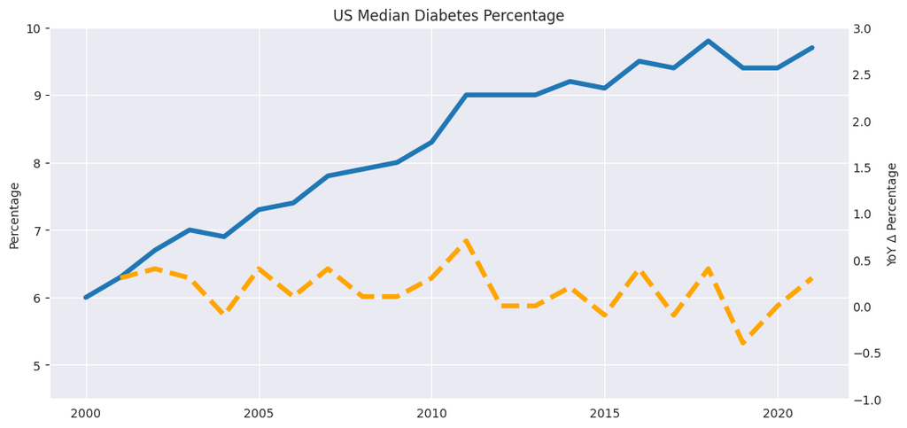

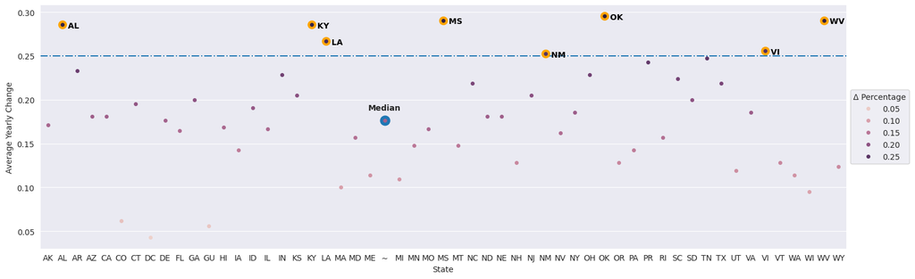

### 6.2 Analysis 2: How might demographic factors contribute to complications and health outcomes of diabetes patients?

*By <Sarah Huang>*

To examine how demographic factors such as age, race, and gender may contribute to health outcomes and complications of diabetes patients, I first used a relevant subset of the dataset from diabetic patients in 130 hospitals from 1999 to 2008 that are related to demographic variables and potential outcomes.

First, I considered the demographic variable of age, and its potential effects on outcomes such as number of medical diagnoses, the number of total procedures (lab and surgical procedures), and the time spent in the hospital for diabetic patients. I used catplots to show the relationship between categorical variables (a demographic variable) and a numerical variable (an outcome variable).

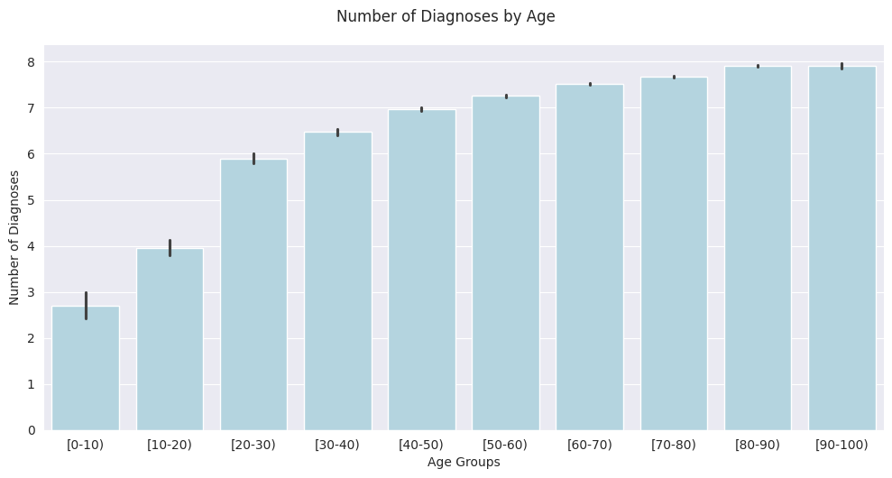

As age increases, it was not unexpected to see that the number of medical diagnoses increased as well given that the body breaks down as we age.

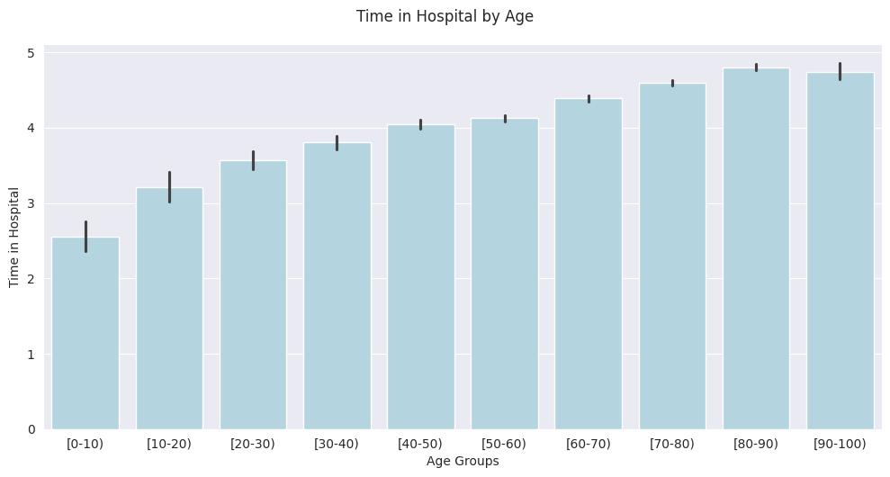

It was not unexpected to see the time in hospital increase as age also increased for similar reasons as to why number of medical diagnoses increased.

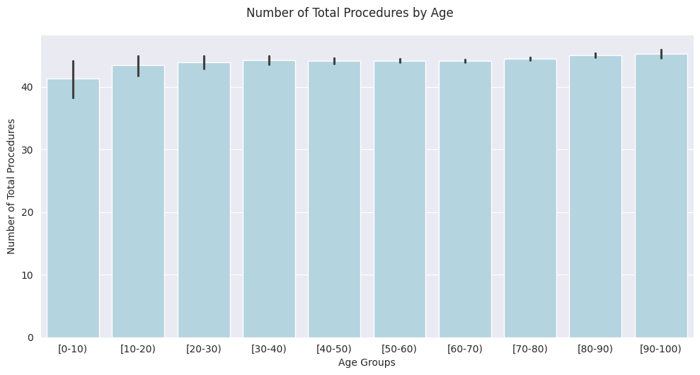

However, despite the number of medical diagnoses and time spent in the hospital increasing along with age, the number of total procedures by age does not change by any statistically significant amount, ranging from 41 to 45 procedures. For the elderly diabetic (considered in the age groups of [70-80), [80-90), and [90-100)), this suggests that despite having worse outcomes, the procedures are the same as other age groups and are not changing to adapt accordingly. This suggests the inefficient use of procedures for diabetic patients across age groups, therefore not optimally improving their health outcomes.

Next, I looked at how gender and racial group might affect outcomes for diabetic patients. I grouped the data by racial group and then assessed for the mean number of emergency visits per year by racial group. I then used catplot to graph the results in a barplot, using gender as the hue to see potential differences between gender.

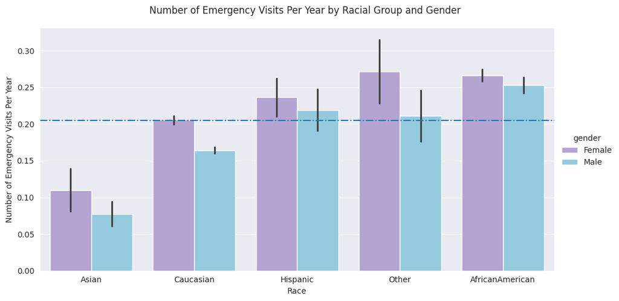

When we focus on gender, we can see that diabetic females seem to have more emergency visits than diabetic males across all racial groups. Specifically, females seem to be 1.22 times more likely to go to the emergency room than males. I was curious as to why this was and decided to do an analysis by gender for other outcomes including number of diagnoses, number of total procedures, time spent in hospital, and number of medications.

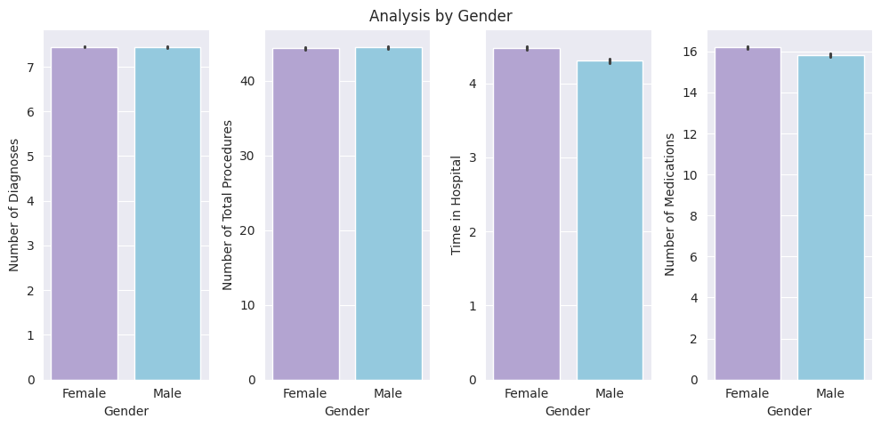

The results were rather unexpected. General female outcomes seem to be relatively consistent with those of males (have the same number of diagnoses, number of total procedures, time spent in hospital, and number of medications). This did not answer as to why diabetic females might have more emergencies than diabetic males. Explanations may lie outside the scope of this dataset since the reasons may be related to sociocultural factors not explored here.

Next, I grouped number of emergencies by race. As mentioned previously, all racial groups have more emergency visits per year compared to Caucasians except diabetic Asians who are 50% less likely to go to the emergency room than Caucasians. I was curious to see if this meant that diabetic Asians had better outcomes than other racial groups, meausured by death and transfers to other facilities for continued care.

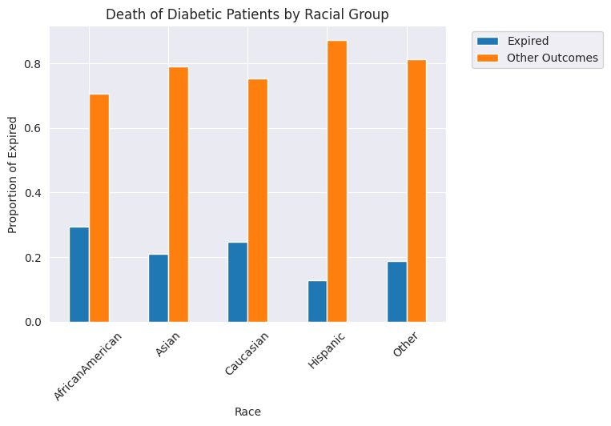

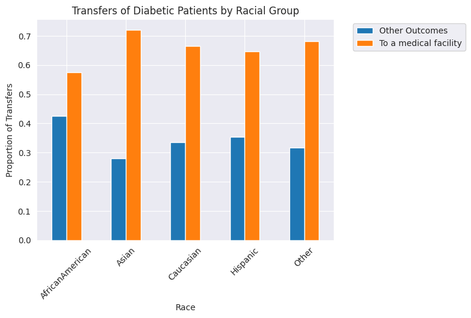

### 6.3 Analysis 3: How might prior medical care contribute to the outcomes of diabetes patients?

*By <Eileen Wang>*

To examine how prior medical care might contribute to the health outcomes of diabetes patients, I created a subset with relevant columns from the dataset from diabetic patients in 130 hospitals from 1999 to 2008 and focused on the admission source column. The admission source codes were organized into the following categories: physician referral, emergency room, hospital transfer, skilled nursing home transfer, and other healthcare facility transfer. Other admission source codes were not used as they either had no observations or did not constitute as prior medical care. I visualized the number of inpatient visits, number of total procedures, and time spent in hospital across these categories, using bar graphs. Number of total procedures was defined as the sum of both lab and other procedures.

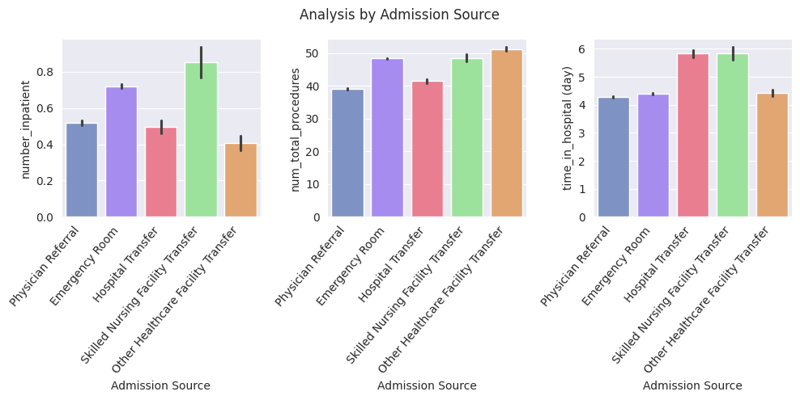

From these graphs, you can see that patients from skilled nursing facilities consistently rank high across all three variables.

Across these admission sources, I also visualized the proportion of patient expiration in hospital, using a bar graph. Dummy variables were first created from the discharge disposition codes and new columns were made based on expiration codes. Expiration out of hospital was not analyzed as the causes of death could have been included other outside sources or confounding variables. Expiration in hospital was assumed to be the better indicator of health outcomes associated with diabetes as the patients would have likely been in the hospital from a condition related to their diabetes.

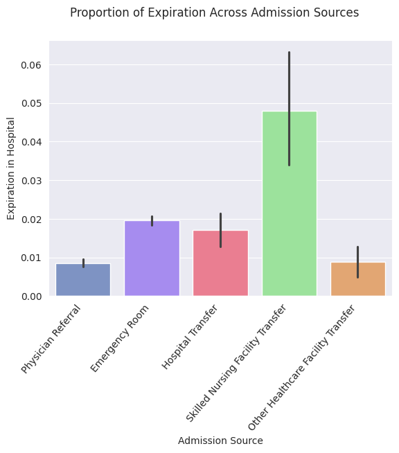

Patients from skilled nursing facility had a proportion of patient expiration that was approximately three times higher than the average expiration proportion from other sources.

The graph was then visualized by age to ensure that age was not a confounding variable. Observations were filtered out if there were 10 or less observations by age across these admission categories to avoid misleading data.

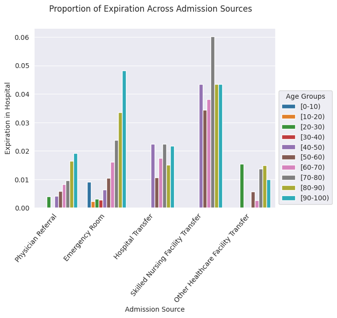

Patients from skilled nursing facilities had higher proportions of patient expiration across most age groups, as well.

### 6.4 Analysis 4: Which drugs are prescribed the most and how might those drugs affect diabetes patients?

*By <Jeffrey Yuan>*

To determine the usage of drugs and the related outcomes of patients using each drug, two variables were determined to be used as outcome measures. The first outcome measure analyzed with each drug was the Glucose Levels of the patients, associated with the max_glu_serum, and the second variable analyzed was the time till readmission for each patient.

In the dataset from diabetic patients in 130 hospitals from 1999 to 2008 there were a total of 23 drugs used.

[output not shown]

To determine the total usage of each drug concerning glucose level, the values of glucose that were ‘None’ were mapped to NaN. The missing values were not imputed because a conclusion based on imputed data can affect downstream conclusions, and inaccurate imputation of glucose levels may lead to incorrect findings in clinical studies and inappropriate medical decisions. The subset of the data with glucose levels was taken for analysis. The total number of patients who used each drug and the corresponding distribution of glucose levels were visualized. Glucose levels were binned into normal levels, levels greater than 200, and levels greater than 300 in the data.

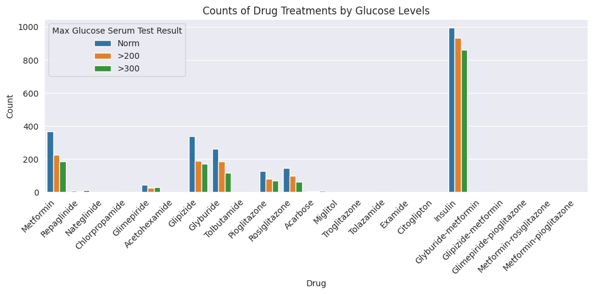

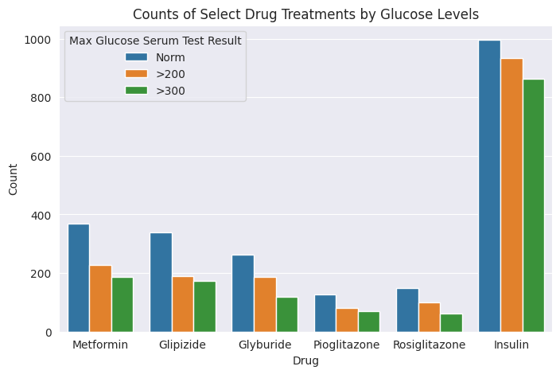

The effectiveness of managing glucose levels was analyzed by finding the proportion of patients in each binned glucose level and visualizing the data.

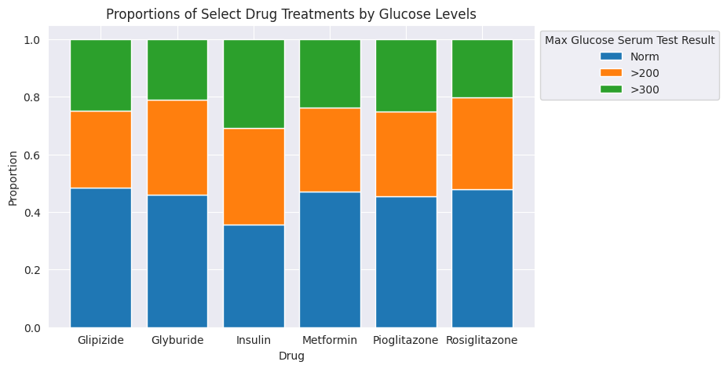

The proportion of patients for each drug who had glucose levels >300 is the highest in insulin at 30%. However, metformin had only 23% of patients with glucose levels>300. Insulin also had the lowest proportion of patients with normal glucose levels at 35%, while metformin had 45% of patients with normal glucose levels.

The top two most common drugs, insulin and metformin, were used to perform a case study on the clinical usage of each drug concerning a patient’s glucose level. For both drugs, the proportion of patients who kept a steady level of drug usage and increased prescription was visualized against the glucose levels.

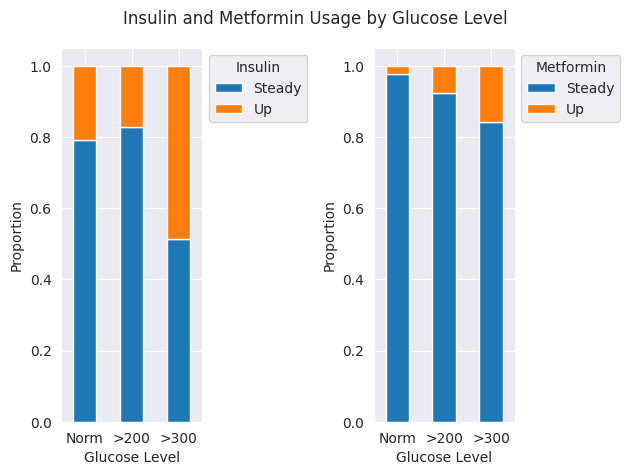

When a patient has worse levels of diabetes progression, the proportion of patients to receive a higher prescription of insulin is much higher than metformin. Of patients with glucose levels >300, 49% receive a higher prescription insulin. A 28% increase in patients with glucose levels >200. However, of patients on a metformin regimen, 15% receive increased metformin, only an 8% increase from patients with glucose levels >200. There is a 20% discrepancy in the increase of clinical insulin prescriptions compared to metformin.

The second outcome measure was readmission. Continuing with the six most common drugs found above, each drug’s proportion of patients in the binned readmission times was visualized. Readmission was binned into patients with no record of readmission, readmitted after 30 days, and readmitted within 30 days. Missing values were not imputed due to potentially false conclusi onimpacting clinical decision-making.

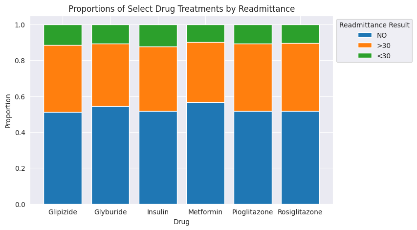

There was not a larger difference in distribution of patients readmisson between all 6 of the most common drugs. There are ~52% of patients not readmitted, ~37% of patients readmitted after 30 days, and ~11% of patients who are readmitted within 30 days of their visit.

### 6.5 Conclusions and Recommendations to Stakeholders

Through our four questions, we found that a diabetic patient’s region, demographics, source of previous treatment, and drug prescription affect a diabetic patient’s health outcomes.

We also saw that certain patient demographics exhibited substantially different outcomes in terms of general health outcomes (number of medical diagnoses, time spent in the hospital, emergency visits per year) and undesired poor health outcomes (proportion of expired, and transfers to medical facilities). In terms of age, general health worsened as age increased time despite the same number of procedures conducted per age group (ranging from 41-45 procedures). This is particularly striking for the elderly population (ages 70-100); even as their general health worsens, the number of procedures–thought to be used to address those health concerns–does not differ from other age groups. This suggests that there may be an inefficient use of standardized procedures across all age groups, especially failing to address the root causes of health problems, particularly in the diabetic elderly. We recommend policymakers research other potential management options for the elderly because current procedures are not improving the general health of the elderly. Additionally, for gender, diabetic females were found to be 1.22 times more likely to return to the emergency room than males. However, general female outcomes seem to be relatively consistent with those of males (same number of diagnoses, number of total procedures, time spent in hospital, and number of medications). Therefore, we suggest further research into the sociocultural factors that may influence why diabetic females visit the emergency room more often than diabetic males. In terms of race, most diabetic minority groups are more likely to go to the emergency room than Caucasians. Compared to Caucasians, Hispanics are 23% more likely and African-Americans are 40% more likely. However, diabetic Asians seem least likely to go to the emergency room, with Asians 50% less likely than Caucasians. However, diabetic Asians have similar proportions of deaths and proportions of medical transfers. Therefore, we suggest clinicians, medical researchers, and policymakers recognize these disparities and devise policies to bridge these gaps.

For Policymakers: Research and develop alternative management strategies for elderly diabetic patients, as current procedures do not sufficiently address their health issues.

For Clinicians and Medical Researchers: Investigate sociocultural factors that may influence the higher emergency room visits among diabetic females. Also, recognize and address the disparities in health outcomes among different racial groups, particularly in emergency care utilization.

Limitations: More data exploration needs to be done to evaluate why racial groups end up in the emergency room more or not. We are not looking at social determinants of health or any other social factors that could contribute to a person’s health outcomes outside of genetic dispositions or things that cannot be changed. In addressing these variables, researchers and clinicians can evaluate how to bridge these gaps to better care for different racial groups.

For previous medical treatment, we found that patients from skilled nursing facilities had a higher proportion of expiration that was three times higher than patients from other sources of medical care. This category of patients was also ranked consistently high in terms of the number of inpatient visits, number of total procedures, and time spent in the hospital, suggesting that they are having more medical issues that require these treatments. As a byproduct of these treatments, these patients are likely to have higher gross medical bills, as well. Therefore, we recommend that policymakers provide more resources to skilled nursing facilities to facilitate better medical care. We also recommend they design insurance plans to help ease the financial burden for those in high-risk groups.

Limitations: More data exploration needs to be done to verify the average gross medical bills of these high-risk groups before designing insurance plans. There could be more exploration in terms of the best way to categorize patients, in terms of designing targeted insurance plans.

Lastly, we found that Insulin was the most commonly prescribed drug to treat diabetes, being prescribed approximately four times more than metformin, the second most highly prescribed drug. However, insulin has the same outcomes as metformin across all levels of diabetes progression, as measured by readmittance rates, and worse outcomes compared to metformin as measured by glucose levels. This prompts the question of whether insulin is the best drug to treat diabetes and whether insulin is being overprescribed. To maintain the same, or worse, outcomes as diabetes worsens, physicians prescribe more and more insulin while metformin prescriptions stay consistent. There is a 28% increase in the proportion of diabetes patients who are prescribed insulin as their symptoms worsen. However, there is only an 8% increase in the proportion of diabetes patients on a metformin regimen. Thus, we recommend physicians use alternative medications, like metformin, to prevent a potential 20% unnecessary over-prescription of medication, which would save costs for providers as well as the patients.

Limitations: Only two outcome measures were used in the analysis. Further study of the physiological outcomes outside of glucose levels needs to be studied to determine the efficacy of each drug. Additional stratification of patients can also be used to determine the efficacy of drug treatment in relation to the social determinants of health.

## References

[1] CDC, “By the Numbers: Diabetes in America,” Centers for Disease Control and Prevention. Accessed: Dec. 02, 2023. [Online]. Available: https://www.cdc.gov/diabetes/health-equity/diabetes-by-the-numbers.html

[2] “National Diabetes Prevention Program | Diabetes | CDC.” Accessed: Dec. 02, 2023. [Online]. Available: https://www.cdc.gov/diabetes/prevention/index.html